# Presentation Exercise

# Presentation Exercise

I chose to recreate a graph that shows the distribution of movie ratings on the star scale from Fandango, IMDb, IMDb users, Metacritic, Metacritic users, and Rotten Tomatoes, and Rotten Tomatoes users.

The graph is depicted below.

[figure not shown]

[Fandango Five Thirty Eight Article](https://fivethirtyeight.com/features/fandango-movies-ratings/)

# Recreating Graph

## Load Packages

```r
library(here)
library(dplyr)
library(ggplot2)
library(readr)
```

## Import Data

```r
here::here()
```

```
[1] "/Users/nataliecann/Library/CloudStorage/OneDrive-UniversityofGeorgia/MADA/nataliecann-MADA-portfolio"
```

```r
#getwd()
#setwd("~/Desktop/MADA/nataliecann-MADA-portfolio/presentation-exercise")
df <- read_csv(here::here("presentation-exercise", "fandango", "fandango_score_comparison.csv"))
```

## Version One: Creating Initial Graph

I used Microsoft Copilot, and occasionally ChatGPT, for this assignment. First, I sent Microsoft Copilot the data nad the graph that I wanted to recreate. I asked it to provide me with code to do so.

Sent Data to Microsoft Copilot Here is the data fandango_score_comparison.csv

Send Microsoft Copilot a .pdf of the graph that I was aiming to recreate fandangocomparison.pdf how do i recreate this graph (with the same shape, rather than a histogram with bars) using the data provided?

Answer: Install and load necessary packages install.packages(“ggplot2”) library(ggplot2)

Read the CSV file df <- read.csv(“path/to/your/fandango_score_comparison.csv”)

Normalize the ratings df$Fandango_Stars_norm <- df$Fandango_Stars / 5 df$Fandango_Ratingvalue_norm <- df$Fandango_Ratingvalue / 5 df$IMDB_norm <- df$IMDB / 10 df$Metacritic_norm <- df$Metacritic / 100 df$Metacritic_User_norm <- df$Metacritic_User / 10 df$RottenTomatoes_norm <- df$RottenTomatoes / 100 df$RottenTomatoes_User_norm <- df$RottenTomatoes_User / 100

Create the density plots ggplot() + geom_density(data = df, aes(x = Fandango_Stars_norm, fill = “Fandango”), alpha = 0.5) + geom_density(data = df, aes(x = Fandango_Ratingvalue_norm, fill = “Fandango Rating Value”), alpha = 0.5) + geom_density(data = df, aes(x = IMDB_norm, fill = “IMDb”), alpha = 0.5) + geom_density(data = df, aes(x = Metacritic_norm, fill = “Metacritic”), alpha = 0.5) + geom_density(data = df, aes(x = Metacritic_User_norm, fill = “Metacritic users”), alpha = 0.5) + geom_density(data = df, aes(x = RottenTomatoes_norm, fill = “Rotten Tomatoes”), alpha = 0.5) + geom_density(data = df, aes(x = RottenTomatoes_User_norm, fill = “Rotten Tomatoes users”), alpha = 0.5) + labs(title = “Normalized Ratings Distribution of 146 Films in Theaters in 2015”, x = “Normalized Rating”, y = “Density”) + scale_fill_manual(name = “Source”, values = c(“Fandango” = “blue”, “Fandango Rating Value” = “cyan”, “IMDb” = “red”, “Metacritic” = “green”, “Metacritic users” = “darkgreen”, “Rotten Tomatoes” = “purple”, “Rotten Tomatoes users” = “violet”)) + theme_minimal()

Save the plot ggsave(“fandangocomparison_replicated.pdf”)

I ran the code in the code chunk below.

```r
# Normalize the ratings
df$Fandango_Stars_norm <- df$Fandango_Stars / 5
df$IMDB_norm <- df$IMDB / 10
df$Metacritic_norm <- df$Metacritic / 100
df$Metacritic_User_norm <- df$Metacritic_User / 10
df$RottenTomatoes_norm <- df$RottenTomatoes / 100
df$RottenTomatoes_User_norm <- df$RottenTomatoes_User / 100

# Create the density plots
version_one <- ggplot() +
  geom_density(data = df, aes(x = Fandango_Stars_norm, fill = "Fandango"), alpha = 0.5) +
  geom_density(data = df, aes(x = IMDB_norm, fill = "IMDb"), alpha = 0.5) +
  geom_density(data = df, aes(x = Metacritic_norm, fill = "Metacritic"), alpha = 0.5) +
  geom_density(data = df, aes(x = Metacritic_User_norm, fill = "Metacritic users"), alpha = 0.5) +
  geom_density(data = df, aes(x = RottenTomatoes_norm, fill = "Rotten Tomatoes"), alpha = 0.5) +
  geom_density(data = df, aes(x = RottenTomatoes_User_norm, fill = "Rotten Tomatoes users"), alpha = 0.5) +
  labs(title = "Normalized Ratings Distribution of 146 Films in Theaters in 2015",
       x = "Normalized Rating",
       y = "Density") +
  scale_fill_manual(name = "Source", values = c("Fandango" = "blue", "IMDb" = "red", "Metacritic" = "green", "Metacritic users" = "darkgreen", "Rotten Tomatoes" = "purple", "Rotten Tomatoes users" = "violet")) +
  theme_minimal()

version_one
```

[figure not shown]

```r
figure_file = here("presentation-exercise", "graphs", "version_one.png")

ggsave(filename = figure_file, plot = version_one) # saving the plot as "version_one"
```

## Version Two: Editing Graph to Better Match the Original Version

I manually edited the colors to fit the ones assigned to each source within the original graph. I simply did this by using hex codes online or typing in basic colors (such as “red”). Additionally, I changed the title under the labs() function.

```r
version_two <- ggplot() +
  geom_density(data = df, aes(x = Fandango_Stars_norm, fill = "Fandango"), alpha = 0.5) +
  geom_density(data = df, aes(x = IMDB_norm, fill = "IMDb"), alpha = 0.5) +
  geom_density(data = df, aes(x = Metacritic_norm, fill = "Metacritic"), alpha = 0.5) +
  geom_density(data = df, aes(x = Metacritic_User_norm, fill = "Metacritic users"), alpha = 0.5) +
  geom_density(data = df, aes(x = RottenTomatoes_norm, fill = "Rotten Tomatoes"), alpha = 0.5) +
  geom_density(data = df, aes(x = RottenTomatoes_User_norm, fill = "Rotten Tomatoes users"), alpha = 0.5) +
  labs(title = "Fandango LOVES Movies",
       x = "Normalized Rating",
       y = "Density") +
  scale_fill_manual(name = "Source", values = c("Fandango" = "red", "IMDb" = "gold", "Metacritic" = "#8d31c1", "Metacritic users" = "#94e13d", "Rotten Tomatoes" = "#7b7b7c", "Rotten Tomatoes users" = "#309dd8")) + # update colors to match those of the original graph
  theme_minimal()

version_two
```

[figure not shown]

```r
figure_file = here("presentation-exercise", "graphs", "version_two.png")

ggsave(filename = figure_file, plot = version_two) # saving the plot as "version_two"
```

## Version Three: Editing Graph MORE to Better Match the Original Version

I asked ChatGPT: how do I get rid of the legend and add the labels within the legend next to their corresponding areas within the graph?

Answer: theme(legend.position = “none”) + # Removes the legend geom_text(aes(x = 1, y = 0.15, label = “Fandango”, color = “red”), size = 5, data = data.frame(), inherit.aes = FALSE) + # Add label for Fandango geom_text(aes(x = 1, y = 0.13, label = “IMDb”, color = “gold”), size = 5, data = data.frame(), inherit.aes = FALSE) + # Add label for IMDb geom_text(aes(x = 1, y = 0.11, label = “Metacritic”, color = “#8d31c1”), size = 5, data = data.frame(), inherit.aes = FALSE) + # Add label for Metacritic geom_text(aes(x = 1, y = 0.09, label = “Metacritic users”, color = “#94e13d”), size = 5, data = data.frame(), inherit.aes = FALSE) + # Add label for Metacritic users geom_text(aes(x = 1, y = 0.07, label = “Rotten Tomatoes”, color = “#7b7b7c”), size = 5, data = data.frame(), inherit.aes = FALSE) + # Add label for Rotten Tomatoes geom_text(aes(x = 1, y = 0.05, label = “Rotten Tomatoes users”, color = “#309dd8”), size = 5, data = data.frame(), inherit.aes = FALSE) # Add label for Rotten Tomatoes users

I manually changed the color of the IMDb users density/text to be a darker gold for better visibility. Additionally, I changed the name that ChatGPT gave me for the label from “IBDb” to “IMDb users” to match the original graph.

After a few more intermediate steps: - I changed the theme of the graph to include a gray background and gray gridlines - I changed the positions of the labels to match the original graph - I fixed the x and y axes - I added a subtitle - I changed geom_density to stat_density and added their respective colors - I made the area under the densities gray with an outline of their respective color

```r
version_three <- ggplot(df) +

   # Adding densities/areas
  stat_density(aes(x = Fandango_Stars_norm, fill = "Fandango"), geom = "area", alpha = 0.5, color = "red") +
  stat_density(aes(x = IMDB_norm, fill = "IMDb"), geom = "area", alpha = 0.5, color = "#e6c531") +
  stat_density(aes(x = Metacritic_norm, fill = "Metacritic"), geom = "area", alpha = 0.5, color = "#8d31c1") +
  stat_density(aes(x = Metacritic_User_norm, fill = "Metacritic users"), geom = "area", alpha = 0.5, color = "#94e13d") +
  stat_density(aes(x = RottenTomatoes_norm, fill = "Rotten Tomatoes"), geom = "area", alpha = 0.5, color = "#7b7b7c") +
  stat_density(aes(x = RottenTomatoes_User_norm, fill = "Rotten Tomatoes users"), geom = "area", alpha = 0.5, color = "#309dd8") +

  # Adding title and subtitle
  labs(title = "Fandango LOVES Movies",
       subtitle = "Normalized ratings distribution of 146 films in theaters in 2015 that \nhad 30+ reviews on Fandango.com",
       x = NULL,
       y = NULL) +

   # Adding fill colors for the densities/areas
  scale_fill_manual(name = "Source", values = c("Fandango" = "#f95858", "IMDb" = "grey", "Metacritic" = "grey", "Metacritic users" = "grey", "Rotten Tomatoes" = "grey", "Rotten Tomatoes users" = "grey")) +

  # Changing background to grey with grey and thin gridlines
  theme_minimal() +
  theme(legend.position = "none",
        plot.background = element_rect(fill = "#ececec"),
        panel.grid.major = element_line(color = "#a7a7a5", size = 0.1),
        panel.grid.minor = element_line(color = "#a7a7a5", size = 0.1),
        panel.grid = element_line(color = "transparent"),
        plot.title = element_text(face = "bold", size = 14),
        plot.subtitle = element_text(size = 10)) +

  # Adding labels and placing them in the appropriate spot on the graph
  geom_text(aes(x = 0.97, y = 3.75, label = "Fandango"), color = "red", size = 2.5, data = data.frame(), inherit.aes = FALSE) +
  geom_text(aes(x = .65, y = 4.2, label = "IMDb users"), color = "#e6c531", size = 2.5, data = data.frame(), inherit.aes = FALSE) +
  geom_text(aes(x = 0.3, y = 1.5, label = "Metacritic"), color = "#8d31c1", size = 2.5, data = data.frame(), inherit.aes = FALSE) +
  geom_text(aes(x = 0.57, y = 2.5, label = "Metacritic \n users"), color = "#94e13d", size = 2.5, data = data.frame(), inherit.aes = FALSE) +
  geom_text(aes(x = 0.1, y = 1.2, label = "Rotten \n Tomatoes"), color = "#7b7b7c", size = 2.5, data = data.frame(), inherit.aes = FALSE) +
  geom_text(aes(x = 0.45, y = 1.9 , label = "Rotten \n Tomatoes \n users"), color = "#309dd8", size = 2.5, data = data.frame(), inherit.aes = FALSE) +

  # Changing the x and y axis labels to match the original graph
  scale_x_continuous(breaks = c(0, 0.2, 0.4, 0.6, 0.8, 1),
                     labels = c("☆", "★", "★★", "★★★", "★★★★", "★★★★★")) +  # the stars appear in the png version
  scale_y_continuous(breaks = c(0, 1, 2, 3, 4),
                     labels = c("0", "10", "20", "30", "40%"))
version_three
```

[figure not shown]

```r
figure_file = here("presentation-exercise", "graphs", "version_three.png")

ggsave(filename = figure_file, plot = version_three) # saving the plot as "version_three"
```

## Version Four: Creating Final Version

For the final version, I made the following changes: - I made the “fandango” label bold (just like it is in the original graph) - I made the font size of the title and subtitle larger - I updated the color of the green in “Metacritic users” to be a bit darker - I removed the “minor” gridlines

Additionally, I asked Microsoft Copilot to change the geom from stat_density to stat_bin. Stat_bin will better help me recreate the original graph than geom_density or stat_density.

Answer: stat_bin(aes(x = Fandango_Stars_norm, fill = “Fandango”), geom = “area”, alpha = 0.5, color = “red”, binwidth = 0.1, position = “identity”) + stat_bin(aes(x = IMDB_norm, fill = “IMDb”), geom = “area”, alpha = 0.5, color = “#f7ca62”, binwidth = 0.1, position = “identity”) + stat_bin(aes(x = Metacritic_norm, fill = “Metacritic”), geom = “area”, alpha = 0.5, color = “#8d31c1”, binwidth = 0.1, position = “identity”) + stat_bin(aes(x = Metacritic_User_norm, fill = “Metacritic users”), geom = “area”, alpha = 0.5, color = “#94e13d”, binwidth = 0.1, position = “identity”) + stat_bin(aes(x = RottenTomatoes_norm, fill = “Rotten Tomatoes”), geom = “area”, alpha = 0.5, color = “#7b7b7c”, binwidth = 0.1, position = “identity”) + stat_bin(aes(x = RottenTomatoes_User_norm, fill = “Rotten Tomatoes users”), geom = “area”, alpha = 0.5, color = “#309dd8”, binwidth = 0.1, position = “identity”) +

After fixing the geom/stat, I realized the y-axis had been messed up. I used code to fix the y-axis and fix the source labels within the graph.

```r
version_four <- ggplot(df) +

   # Adding densities/areas
  stat_bin(aes(x = IMDB_norm, fill = "IMDb"), geom = "area", alpha = 0.5, color = "#e6c531", binwidth = 0.1, position = "identity") +
  stat_bin(aes(x = Metacritic_norm, fill = "Metacritic"), geom = "area", alpha = 0.5, color = "#8d31c1", binwidth = 0.1, position = "identity") +
  stat_bin(aes(x = Metacritic_User_norm, fill = "Metacritic users"), geom = "area", alpha = 0.5, color = "#87c866", binwidth = 0.1, position = "identity") +
  stat_bin(aes(x = RottenTomatoes_norm, fill = "Rotten Tomatoes"), geom = "area", alpha = 0.5, color = "#7b7b7c", binwidth = 0.1, position = "identity") +
  stat_bin(aes(x = RottenTomatoes_User_norm, fill = "Rotten Tomatoes users"), geom = "area", alpha = 0.5, color = "#309dd8", binwidth = 0.1, position = "identity") + stat_bin(aes(x = Fandango_Stars_norm, fill = "Fandango"), geom = "area", alpha = 0.5, color = "red", binwidth = 0.1, position = "identity") +

  # Adding title and subtitle
  labs(title = "Fandango LOVES Movies",
       subtitle = "Normalized ratings distribution of 146 films in theaters in 2015 that \nhad 30+ reviews on Fandango.com",
       x = NULL,
       y = NULL) +

   # Adding fill colors for the densities/areas
  scale_fill_manual(name = "Source", values = c("Fandango" = "#f95858", "IMDb" = "grey", "Metacritic" = "grey", "Metacritic users" = "grey", "Rotten Tomatoes" = "grey", "Rotten Tomatoes users" = "grey")) +

  # Changing background to grey with grey and thin gridlines
theme_minimal() +
  theme(legend.position = "none",
        plot.background = element_rect(fill = "#ececec"),
        panel.grid.major = element_line(color = "#a7a7a5", size = 0.1),
        panel.grid = element_line(color = "transparent"),
        plot.title = element_text(face = "bold", size = 18),  # Bigger title
        plot.subtitle = element_text(size = 14)) +  # Bigger subtitle

  # Adding labels and placing them in the appropriate spot on the graph
  geom_text(aes(x = 0.97, y = 55, label = "Fandango"), color = "red", size = 3.2, fontface = "bold", data = data.frame(), inherit.aes = FALSE) + # only bold "Fandango"
  geom_text(aes(x = .6, y = 60, label = "IMDb users"), color = "#e6c531", size = 3.2, data = data.frame(), inherit.aes = FALSE) +
  geom_text(aes(x = 0.3, y = 23, label = "Metacritic"), color = "#8d31c1", size = 3.2, data = data.frame(), inherit.aes = FALSE) +
  geom_text(aes(x = 0.55, y = 37, label = "Metacritic \n users"), color = "#87c866", size = 3.2, data = data.frame(), inherit.aes = FALSE) +
  geom_text(aes(x = 0.1, y = 19, label = "Rotten \n Tomatoes"), color = "#7b7b7c", size = 3.2, data = data.frame(), inherit.aes = FALSE) +
  geom_text(aes(x = 0.45, y = 30 , label = "Rotten \n Tomatoes \n users"), color = "#309dd8", size = 3.2, data = data.frame(), inherit.aes = FALSE) +

  # Changing the x and y axis labels to match the original graph
  scale_x_continuous(breaks = c(0, 0.2, 0.4, 0.6, 0.8, 1),
                     labels = c("☆", "★", "★★", "★★★", "★★★★", "★★★★★")) +  # the stars appear in the png version
  scale_y_continuous(breaks = c(0, 15, 30, 45, 60),
                     labels = c("0", "10", "20", "30", "40%"))

version_four
```

[figure not shown]

```r
figure_file = here("presentation-exercise", "graphs", "version_four.png")

ggsave(filename = figure_file, plot = version_four) # saving the plot as "version_four"
```

## Final Version of Graph vs Original Graph

The stars used on the x-axis to represent the ratings did not appear in the output on my computer in R Studio. However, the stars appear in the .png file attached below.

[figure not shown]

For the most part, I believe that I was able to successfully recreate the original graph. It appears that the distriution of the ratings among the different sources is pretty similar to that of the original graph. There are miniscule differences. Another element that I had difficulty in recreating from the original graph was making the areas overlap in the same way that they do in the original graph.

# Creating Publication Quality Table

## Load Packages

```r
library(dplyr)
library(tidyr)
library(kableExtra)
library(gt)
library(stringr)
library(webshot2)
library(htmltools)
library(purrr)
```

## Create Table

I used Microsoft Copilot and ChatGPT. I asked it to create a graph in which the columns were: mean, median, minimum, maximum rating values, and distribution plot. I asked for the rows to be: Fandango, IMDb, IMDb users, Metacritic, Metacritic users, Rotten Tomatoes, and Rotten Tomatoes users. There were MANY small things that I had to fix.

```r
# Load required libraries
library(dplyr)
library(tidyr)
library(gt)
library(purrr)

# Step 1: Summarize the data
table <- df %>%
  select(Fandango_Stars_norm, IMDB_norm, Metacritic_norm, Metacritic_User_norm, RottenTomatoes_norm, RottenTomatoes_User_norm) %>%
  summarise(
    Fandango_mean = mean(Fandango_Stars_norm, na.rm = TRUE),
    Fandango_median = median(Fandango_Stars_norm, na.rm = TRUE),
    Fandango_min = min(Fandango_Stars_norm, na.rm = TRUE),
    Fandango_max = max(Fandango_Stars_norm, na.rm = TRUE),

    IMDB_mean = mean(IMDB_norm, na.rm = TRUE),
    IMDB_median = median(IMDB_norm, na.rm = TRUE),
    IMDB_min = min(IMDB_norm, na.rm = TRUE),
    IMDB_max = max(IMDB_norm, na.rm = TRUE),

    Metacritic_mean = mean(Metacritic_norm, na.rm = TRUE),
    Metacritic_median = median(Metacritic_norm, na.rm = TRUE),
    Metacritic_min = min(Metacritic_norm, na.rm = TRUE),
    Metacritic_max = max(Metacritic_norm, na.rm = TRUE),

    Metacritic_User_mean = mean(Metacritic_User_norm, na.rm = TRUE),
    Metacritic_User_median = median(Metacritic_User_norm, na.rm = TRUE),
    Metacritic_User_min = min(Metacritic_User_norm, na.rm = TRUE),
    Metacritic_User_max = max(Metacritic_User_norm, na.rm = TRUE),

    RottenTomatoes_mean = mean(RottenTomatoes_norm, na.rm = TRUE),
    RottenTomatoes_median = median(RottenTomatoes_norm, na.rm = TRUE),
    RottenTomatoes_min = min(RottenTomatoes_norm, na.rm = TRUE),
    RottenTomatoes_max = max(RottenTomatoes_norm, na.rm = TRUE),

    RottenTomatoes_User_mean = mean(RottenTomatoes_User_norm, na.rm = TRUE),
    RottenTomatoes_User_median = median(RottenTomatoes_User_norm, na.rm = TRUE),
    RottenTomatoes_User_min = min(RottenTomatoes_User_norm, na.rm = TRUE),
    RottenTomatoes_User_max = max(RottenTomatoes_User_norm, na.rm = TRUE)
  )

# Step 2: Reshape the data
table_long <- table %>%
  pivot_longer(cols = everything(), names_to = c("Rating", "Statistic"), names_pattern = "(.*)_(.*)") %>%
  pivot_wider(names_from = "Statistic", values_from = "value") %>%
  select(Rating, mean, median, min, max)

# Step 3: Add the distribution plot path and other steps
get_image_path <- function(rating) {
  # Modify the function to return the correct image path or URL
  paste0("path_to_images/", rating, "_plot.png")  # Example path, adjust to your data
}

table_with_plots <- table_long %>%
  mutate(
    distribution = map(Rating, get_image_path)
  )

# Compute the maximum values for highlighting
max_mean <- max(table_long$mean, na.rm = TRUE)
max_median <- max(table_long$median, na.rm = TRUE)
max_min <- max(table_long$min, na.rm = TRUE)
max_max <- max(table_long$max, na.rm = TRUE)


# Step 4: Create and format the GT table
# Create the presentation table with images using text_transform
presentation_table <- table_with_plots %>%
  gt() %>%
  tab_header(
    title = md("**Summary of Ratings from Movie Review Sources**")
  ) %>%
  cols_label(
    Rating = "Rating Source",
    mean = "Mean",
    median = "Median",
    min = "Minimum",
    max = "Maximum",
    distribution = "Density Plot"
  ) %>%
  tab_spanner(
    label = "Rating Statistics",
    columns = c("mean", "median", "min", "max")
  ) %>%
  tab_style(
    style = list(cell_text(weight = "bold")),
    locations = cells_column_labels(columns = c("mean", "median", "min", "max"))
  ) %>%
  tab_style(
    style = list(cell_text(weight = "bold")),
    locations = cells_column_labels(columns = everything())
  ) %>%
  # Use text_transform to render HTML <img> tags for images
  text_transform(
    locations = cells_body(columns = "distribution"),
    fn = function(x) {
      map(x, ~ ifelse(!is.na(.x),
                      paste0('<img src="file://', file.path("~/Desktop/MADA/nataliecann-MADA-portfolio/presentation-exercise/graphs", .x), '" height="100">'),
                      NA_character_))
    }
  ) %>%
  tab_style(
    style = cell_fill(color = "white"),
    locations = cells_body(rows = seq(1, nrow(table_with_plots), by = 2))
  ) %>%
  tab_style(
    style = cell_fill(color = "#ececec"),
    locations = cells_body(rows = seq(2, nrow(table_with_plots), by = 2))
  ) %>%
  tab_style(
    style = cell_fill(color = "#dbf2cf"),
    locations = cells_body(columns = "mean", rows = mean == max_mean)
  ) %>%
  tab_style(
    style = cell_fill(color = "#cfedf8"),
    locations = cells_body(columns = "median", rows = median == max_median)
  ) %>%
  tab_style(
    style = cell_fill(color = "#f5e4f3"),
    locations = cells_body(columns = "min", rows = min == max_min)
  ) %>%
  tab_style(
    style = cell_fill(color = "#fee6cc"),
    locations = cells_body(columns = "max", rows = max == max_max)
  ) %>%
  tab_source_note(
    source_note = md("*Cells highlighted in different colors indicate the highest value in that column.*")
  )

# Display the table
presentation_table
```

**Summary of Ratings from Movie Review Sources**

| Rating Source | Rating Statistics Mean | Rating Statistics Median | Rating Statistics Minimum | Rating Statistics Maximum | Density Plot |  |
| --- | --- | --- | --- | --- | --- | --- |
| Fandango | 0.8178082 | 0.800 | 0.60 | 1.00 |  |  |
| IMDB | 0.6736986 | 0.690 | 0.40 | 0.86 |  |  |
| Metacritic | 0.5880822 | 0.590 | 0.13 | 0.94 |  |  |
| Metacritic_User | 0.6519178 | 0.685 | 0.24 | 0.96 |  |  |
| RottenTomatoes | 0.6084932 | 0.635 | 0.05 | 1.00 |  |  |
| RottenTomatoes_User | 0.6387671 | 0.665 | 0.20 | 0.94 |  |  |

*Cells highlighted in different colors indicate the highest value in that column.*

```r
# Save!
gtsave(presentation_table, "presentation_table.png")
```

```r
# Define common scales
common_x_scale <- scale_x_continuous(
  breaks = c(0, 0.2, 0.4, 0.6, 0.8, 1),
  labels = c("☆", "★", "★★", "★★★", "★★★★", "★★★★★")
)

common_y_scale <- scale_y_continuous(
  breaks = c(0, 15, 30, 45, 60),
  labels = c("0", "10", "20", "30", "40%")
)

common_theme <- theme_minimal() +
  theme(
    legend.position = "none",
    plot.background = element_rect(fill = "#ececec"),
    panel.grid.major = element_line(color = "#a7a7a5", size = 0.1),
    panel.grid = element_line(color = "transparent"),
    plot.title = element_text(face = "bold", size = 18),
    plot.subtitle = element_text(size = 14)
  )

# IMDb Plot
IMDb <- ggplot(df) +
  stat_bin(aes(x = IMDB_norm, fill = "IMDb"), geom = "area", alpha = 0.5, color = "#e6c531", binwidth = 0.1, position = "identity") +
  scale_fill_manual(values = c("IMDb" = "#e6c531")) +
  common_x_scale + common_y_scale + common_theme
IMDb
```

[figure not shown]

```r
# Metacritic Plot
Metacritic <- ggplot(df) +
  stat_bin(aes(x = Metacritic_norm, fill = "Metacritic"), geom = "area", alpha = 0.5, color = "#8d31c1", binwidth = 0.1, position = "identity") +
  scale_fill_manual(values = c("Metacritic" = "#8d31c1")) +
  common_x_scale + common_y_scale + common_theme
Metacritic
```

[figure not shown]

```r
# Metacritic User Plot
Metacritic_User <- ggplot(df) +
  stat_bin(aes(x = Metacritic_User_norm, fill = "Metacritic users"), geom = "area", alpha = 0.5, color = "#87c866", binwidth = 0.1, position = "identity") +
  scale_fill_manual(values = c("Metacritic users" = "#87c866")) +
  common_x_scale + common_y_scale + common_theme
Metacritic_User
```

[figure not shown]

```r
# Rotten Tomatoes Plot
RottenTomatoes <- ggplot(df) +
  stat_bin(aes(x = RottenTomatoes_norm, fill = "Rotten Tomatoes"), geom = "area", alpha = 0.5, color = "#7b7b7c", binwidth = 0.1, position = "identity") +
  scale_fill_manual(values = c("Rotten Tomatoes" = "#7b7b7c")) +
  common_x_scale + common_y_scale + common_theme
RottenTomatoes
```

[figure not shown]

```r
# Rotten Tomatoes User Plot
RottenTomatoes_User <- ggplot(df) +
  stat_bin(aes(x = RottenTomatoes_User_norm, fill = "Rotten Tomatoes users"), geom = "area", alpha = 0.5, color = "#309dd8", binwidth = 0.1, position = "identity") +
  scale_fill_manual(values = c("Rotten Tomatoes users" = "#309dd8")) +
  common_x_scale + common_y_scale + common_theme
RottenTomatoes_User
```

[figure not shown]

```r
# Fandango Plot
Fandango <- ggplot(df) +
  stat_bin(aes(x = Fandango_Stars_norm, fill = "Fandango"), geom = "area", alpha = 0.5, color = "red", binwidth = 0.1, position = "identity") +
  scale_fill_manual(values = c("Fandango" = "red")) +
  common_x_scale + common_y_scale + common_theme
Fandango
```

[figure not shown]

I tried many different times to get the distributions to appear in the “density plot” column. I couldn’t get this to work. So, I took screenshots of the individual graphs created above and edited them into a screenshot of the table. The screenshot can be seen below:

[figure not shown]

Edited Version of Table

# Redoing Presentation Table

I will redo the presentation table after looking over my classmate’s methods so that I can save the images properly and add them to the table.

**Summary Statistics for Movie Review Sources**

Source

**Summary Statistics**

Distribution

Mean (SD)

Median (Q1, Q3)

Min

Max

Fandango

0.82 (0.11)

0.8 (0.7, 0.9)

0.60

1.00

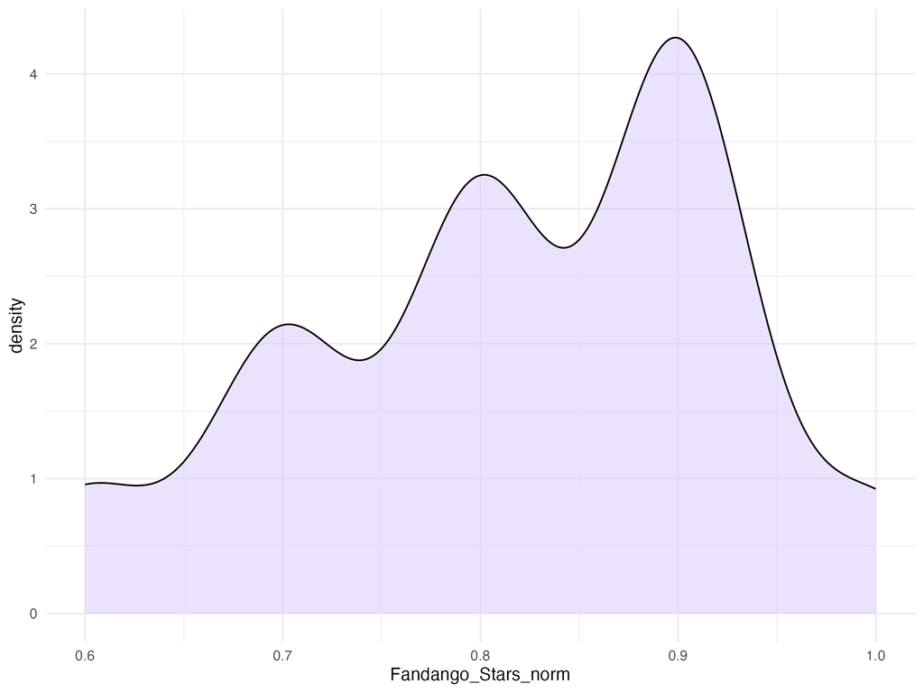

Rotten Tomatoes

0.61 (0.3)

0.64 (0.31, 0.89)

0.05

1.00

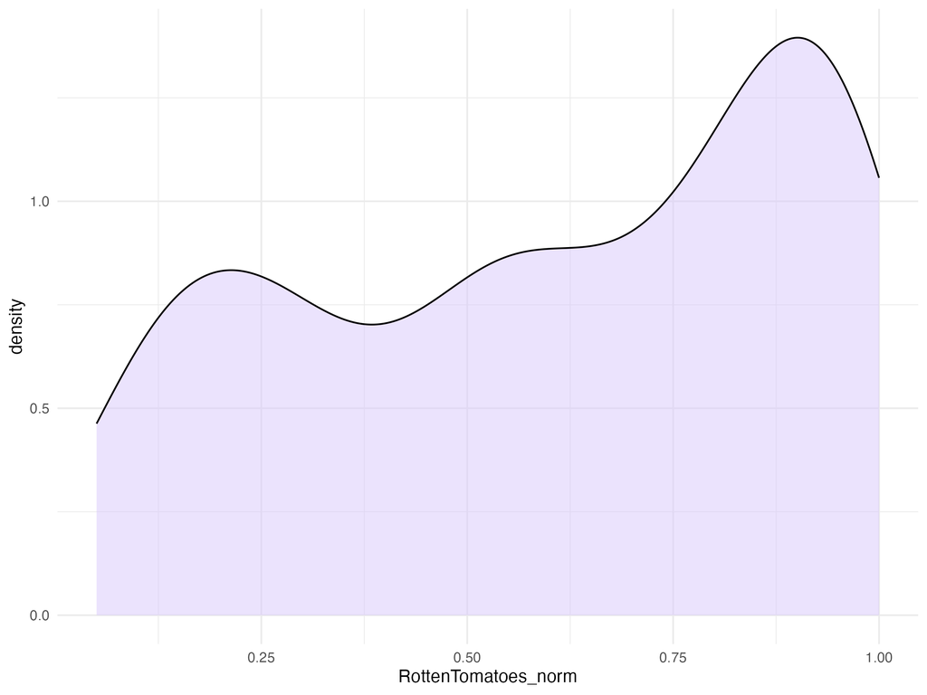

Rotten Tomatoes users

0.64 (0.2)

0.66 (0.5, 0.81)

0.20

0.94

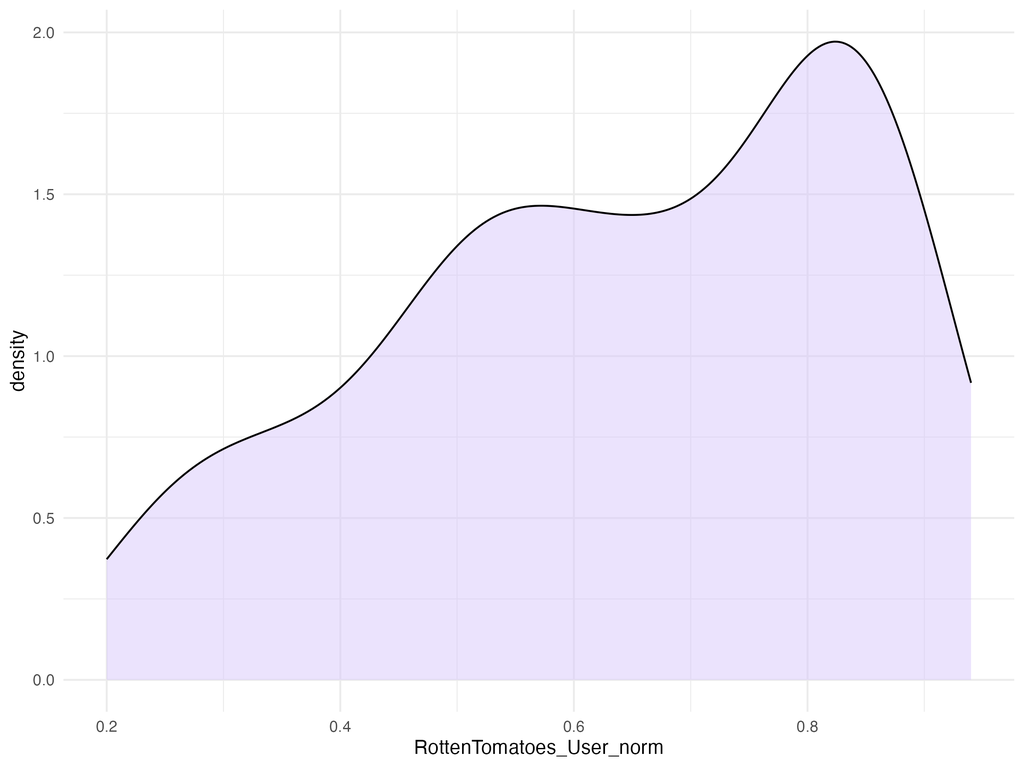

Metacritic

0.59 (0.2)

0.59 (0.44, 0.75)

0.13

0.94

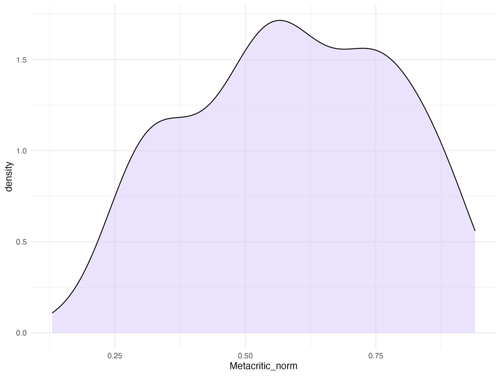

Metacritic users

0.65 (0.15)

0.69 (0.57, 0.75)

0.24

0.96

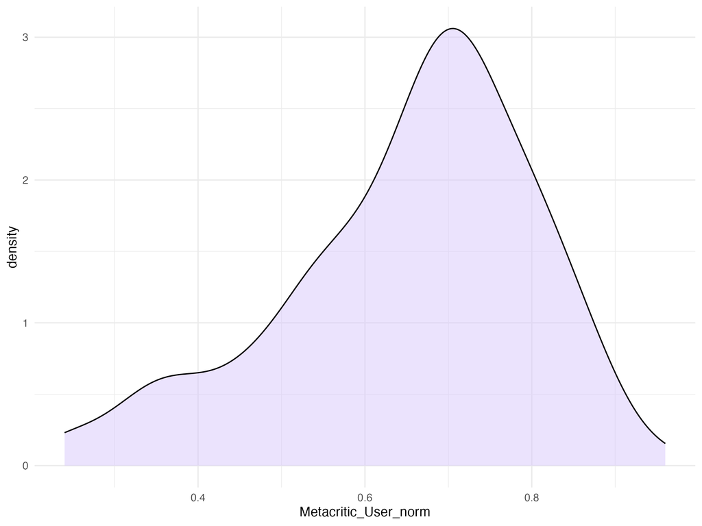

IMDb users

0.67 (0.1)

0.69 (0.63, 0.74)

0.40

0.86

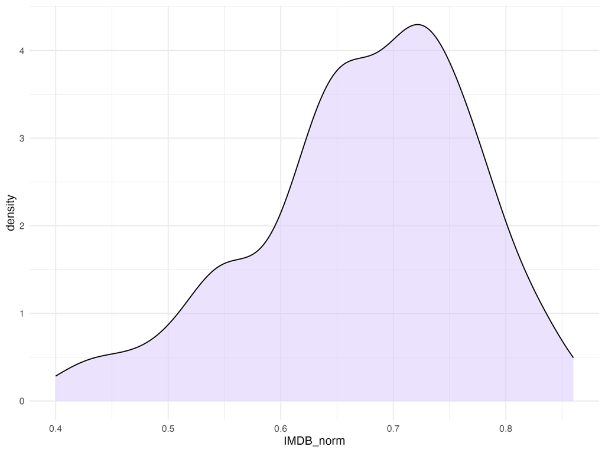

This table compares summary statistics mean, median, min, and max for ratings across various movie rating sources. The highest value within the mean column is highlighted blue, the highest value within the median value is highlighted green, the highest value within the min column is highlighted yellow, and the highest value within the max column is highlighted pink.

```r
# Library loading of packages
library(dplyr)
library(kableExtra)
library(gt)
library(ggplot2)

# Vector of movie rating source names
source_names <- c(
  "Fandango_Stars_norm" = "Fandango",
  "RottenTomatoes_norm" = "Rotten Tomatoes",
  "RottenTomatoes_User_norm" = "Rotten Tomatoes users",
  "Metacritic_norm" = "Metacritic",
  "Metacritic_User_norm" = "Metacritic users",
  "IMDB_norm" = "IMDb users"
)

# Vector of variables to plot
variables <- c("Fandango_Stars_norm", "RottenTomatoes_norm", "RottenTomatoes_User_norm",
               "Metacritic_norm", "Metacritic_User_norm", "IMDB_norm")

# Function to generate and save distribution plots
generate_distribution_plots <- function(variable) {
  # Create the plot (density plot in this case)
  p <- ggplot(df, aes_string(x = variable)) +
    geom_density(fill = "#d8c8fb", alpha = 0.5) +
    theme_minimal()

  # Save the plot as PNG
  file_name <- paste0(variable, "_distribution.png")
  ggsave(file_name, plot = p, width = 8, height = 6)

  # Return the file path
  return(file_name)
}

# Generate and save the distribution plots for each variable
plot_paths <- sapply(variables, generate_distribution_plots)
# Function to generate image file paths (replace with real image paths)
generate_image_path <- function(source_name) {
  image_urls <- c(
    "Fandango" = "Fandango_Stars_norm_distribution.png",
    "Rotten Tomatoes" = "RottenTomatoes_norm_distribution.png",
    "Rotten Tomatoes users" = "RottenTomatoes_User_norm_distribution.png",
    "Metacritic" = "Metacritic_norm_distribution.png",
    "Metacritic users" = "Metacritic_User_norm_distribution.png",
    "IMDb users" = "IMDB_norm_distribution.png"
  )

  return(image_urls[source_name])
}

# Sources for which summary statistics are needed
sources <- c("Fandango_Stars_norm", "RottenTomatoes_norm", "RottenTomatoes_User_norm",
             "Metacritic_norm", "Metacritic_User_norm", "IMDB_norm")

# Initialize an empty dataframe to store the summary stats
summary_stats <- data.frame()

# Compute summary statistics for each platform and append them
for (source in sources) {
  stats <- df %>%
    summarise(
      `Source` = source_names[source],
      `Mean (SD)` = paste0(round(mean(get(source)), 2), " (", round(sd(get(source)), 2), ")"),
      `Median (Q1, Q3)` = paste0(round(median(get(source)), 2), " (",
                                 round(quantile(get(source), 0.25), 2), ", ",
                                 round(quantile(get(source), 0.75), 2), ")"),
      Min = round(min(get(source)), 2),
      Max = round(max(get(source)), 2),
      Distribution = generate_image_path(source_names[source])  # Correct reference to 'source_names'
    )

  # Append the stats to summary_stats
  summary_stats <- bind_rows(summary_stats, stats)
}

# Create the presentation table
presentation_table_redo <- summary_stats %>%
  gt() %>%
  # Adding header that spans multiple columns
  tab_header(
    title = md("**Summary Statistics for Movie Review Sources**")  # Bold the title
  ) %>%
  tab_spanner(
    label = md("**Summary Statistics**"),
    columns = c(`Mean (SD)`, `Median (Q1, Q3)`, Min, Max)
  ) %>%
  # Adding a source note with explanation
  tab_source_note(
    source_note = md("This table compares summary statistics mean, median, min, and max for ratings across various movie rating sources. The highest value within the mean column is highlighted blue, the highest value within the median value is highlighted green, the highest value within the min column is highlighted yellow, and the highest value within the max column is highlighted pink.")
  ) %>%
  # Bold specific column labels: Mean (SD), Median (Q1, Q3), Min, Max
  tab_style(
    style = cell_text(weight = "bold"),
    locations = cells_column_labels(columns = c("Mean (SD)", "Median (Q1, Q3)", "Min", "Max"))
  ) %>%
  # Bold the "Source" column label and all its body cells
  tab_style(
    style = cell_text(weight = "bold"),
    locations = cells_column_labels(columns = "Source")
  ) %>%
  tab_style(
    style = cell_text(weight = "bold"),
    locations = cells_body(columns = "Source")
  ) %>%
  # Bold the "Distribution" column label and all its body cells
  tab_style(
    style = cell_text(weight = "bold"),
    locations = cells_column_labels(columns = "Distribution")
  ) %>%
  tab_style(
    style = cell_text(weight = "bold"),
    locations = cells_body(columns = "Distribution")
  ) %>%
  # Alternating row colors for readability (white for odd rows and light gray for even rows)
  tab_style(
    style = cell_fill(color = "white"),
    locations = cells_body(rows = seq(1, nrow(summary_stats), by = 2))
  ) %>%
  tab_style(
    style = cell_fill(color = "#ececec"),
    locations = cells_body(rows = seq(2, nrow(summary_stats), by = 2))
  ) %>%
  # Displaying images in the new 'Distribution' column
  fmt_image(
    columns = "Distribution",
    rows = everything(),
    path = NULL,  # Path is not required if you're using URLs
    file_pattern = "{x}",
    encode = TRUE
  ) %>%
  # Add alternating color for each row based on index
  tab_style(
    style = cell_fill(color = "#f9f9f9"),
    locations = cells_body(rows = seq(1, nrow(summary_stats), by = 2))
  ) %>%
  tab_style(
    style = cell_fill(color = "#f2f2f2"),
    locations = cells_body(rows = seq(2, nrow(summary_stats), by = 2))
  ) %>%
  # Conditional formatting for the highest "Mean" value (highlight in blue)
  tab_style(
    style = cell_fill(color = "#d1e9fc"),
    locations = cells_body(
      columns = "Mean (SD)",
      rows = which(summary_stats$`Mean (SD)` == max(summary_stats$`Mean (SD)`))
    )
  ) %>%
  # Conditional formatting for the highest "Median" value (highlight in green)
  tab_style(
    style = cell_fill(color = "#cff2d0"),
    locations = cells_body(
      columns = "Median (Q1, Q3)",
      rows = which(summary_stats$`Median (Q1, Q3)` == max(summary_stats$`Median (Q1, Q3)`))
    )
  ) %>%
  # Conditional formatting for the highest "Min" value (highlight in yellow)
  tab_style(
    style = cell_fill(color = "#fafabf"),
    locations = cells_body(
      columns = "Min",
      rows = which(summary_stats$Min == max(summary_stats$Min))
    )
  ) %>%
  # Conditional formatting for the highest "Max" value (highlight in pink)
  tab_style(
    style = cell_fill(color = "#fae1eb"),
    locations = cells_body(
      columns = "Max",
      rows = which(summary_stats$Max == max(summary_stats$Max))
    )
  )

# Display the table
presentation_table_redo
```

```r
# Save the table as a PNG image
gtsave(presentation_table_redo, "presentation_table_redo.png")
```

As one can see from analyzing the table above, the source “Fandango” appears to have the highest ratings according to the summary statistics.